# Fibrotic Memory of Fibroblasts Analysis

Tawaun Lucas

11/28/2023

Data has been reprocessed to exclude those cells that did not have both ATAC and gene expression. This allows for better downstream analysis in ArchR.

# Setup Environment

```r
#load the ArchR library
library(ArchR)
library(grid)
library(gridExtra)
library(dsassembly)
#set a seed to facilitate replication of operations requiring randomization
set.seed(824)

#default number of Parallel threads is 16
# working on a local computer, 1 thread works best
addArchRThreads(14)

#Before we begin, we need add a reference genome annotation for ArchR
#to have access to chromosome and gene information. ArchR supports hg19, hg38, mm9, and mm10.
addArchRGenome("hg38")
data.dir <- "/gstore/scratch/u/lucast3/fibroticmemory" # setdirectory for files
```

# Load Project

```r
projMulti2 <- loadArchRProject(file.path(data.dir,"Save-ProjMulti2"),
                        showLogo = FALSE)
```

# Analysis of multiome data in ArchR

The first thing we will do is perform dimensionality reduction We can do this on the scATAC-seq data via the `TileMatrix` and on the scRNA-seq data via the `GeneExpressionMatrix`. ## ATAC Dim Reduc

```r
projMulti2 <- addIterativeLSI(
  ArchRProj = projMulti2,
  clusterParams = list(
    resolution = 0.2,
    sampleCells = 10000,
    n.start = 10
  ),
  saveIterations = FALSE,
  useMatrix = "TileMatrix",
  depthCol = "nFrags",
  name = "LSI_ATAC"
)
```

## RNA Dim Reduc

```r
projMulti2 <- addIterativeLSI(
  ArchRProj = projMulti2,
  clusterParams = list(
    resolution = 0.2,
    sampleCells = 10000,
    n.start = 10
  ),
  saveIterations = FALSE,
  useMatrix = "GeneExpressionMatrix",
  depthCol = "Gex_nUMI",
  varFeatures = 2500,
  firstSelection = "variable",
  binarize = FALSE,
  name = "LSI_RNA"
)
```

## Combined Dim Reduc

We can also create a dimensionality reduction that uses information from both the scATAC-seq and scRNA-seq data. We will name this `reducedDims` object “LSI_Combined”.

```r
projMulti2 <- addCombinedDims(projMulti2, reducedDims = c("LSI_ATAC", "LSI_RNA"), name =  "LSI_Combined",corCutOff = 0.75)
```

```r
# Need to order colnames so that findclusters will run
colnames(projMulti2@reducedDims$LSI_Combined$matRD)[1:28]<-1:28
colnames(projMulti2@reducedDims$LSI_Combined$matRD)[29:58]<-1:30
projMulti2@reducedDims$LSI_Combined$matRD <- projMulti2@reducedDims$LSI_Combined$matRD[,order(as.numeric(colnames(projMulti2@reducedDims$LSI_Combined$matRD)))]
```

We can create UMAP embeddings for each of these dimensionality reductions. ### Adding UMAP

```r
projMulti2 <- addUMAP(projMulti2, reducedDims = "LSI_ATAC", name = "UMAP_ATAC", minDist = 0.8, force = TRUE)
projMulti2 <- addUMAP(projMulti2, reducedDims = "LSI_RNA", name = "UMAP_RNA", minDist = 0.8, force = TRUE)
projMulti2 <- addUMAP(projMulti2, reducedDims = "LSI_Combined", name = "UMAP_Combined", minDist = 0.8, force = TRUE)
```

And then call clusters for each. ### Adding Clusters

```r
projMulti2 <- addClusters(projMulti2, reducedDims = "LSI_ATAC", name = "Clusters_ATAC", resolution = 0.4, force = TRUE)
## Modularity Optimizer version 1.3.0 by Ludo Waltman and Nees Jan van Eck
##
## Number of nodes: 28351
## Number of edges: 932408
##
## Running Louvain algorithm...
## Maximum modularity in 10 random starts: 0.8875
## Number of communities: 18
## Elapsed time: 3 seconds
projMulti2 <- addClusters(projMulti2, reducedDims = "LSI_RNA", name = "Clusters_RNA", resolution = 0.4, force = TRUE)
## Modularity Optimizer version 1.3.0 by Ludo Waltman and Nees Jan van Eck
##
## Number of nodes: 28351
## Number of edges: 978809
##
## Running Louvain algorithm...
## Maximum modularity in 10 random starts: 0.9227
## Number of communities: 12
## Elapsed time: 4 seconds
projMulti2 <- addClusters(projMulti2, reducedDims = "LSI_Combined", name = "Clusters_Combined", resolution = 0.4, force = TRUE)
## Modularity Optimizer version 1.3.0 by Ludo Waltman and Nees Jan van Eck
##
## Number of nodes: 28351
## Number of edges: 1226510
##
## Running Louvain algorithm...
## Maximum modularity in 10 random starts: 0.9183
## Number of communities: 13
## Elapsed time: 4 seconds
```

We can plot how each of these dimensionality reductions look with respect to the clusters called in “LSI_Combined”. ### Plotting Clusters

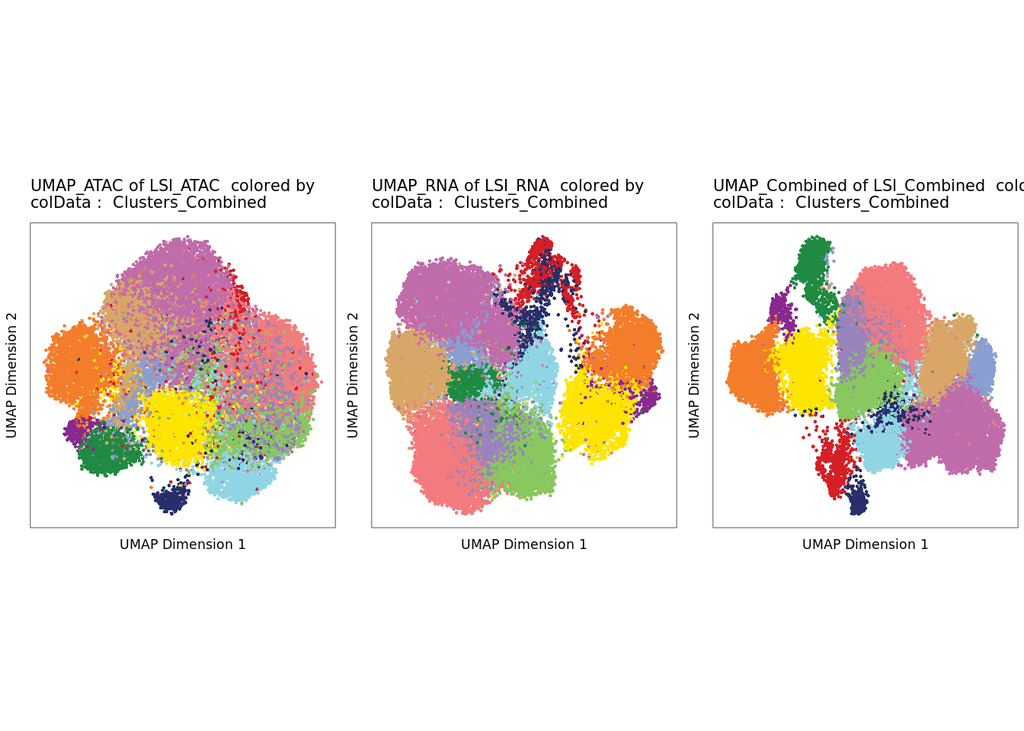

```r
p1 <- plotEmbedding(projMulti2, name = "Clusters_Combined", embedding = "UMAP_ATAC", size = 1, labelAsFactors=F, labelMeans=F)
p2 <- plotEmbedding(projMulti2, name = "Clusters_Combined", embedding = "UMAP_RNA", size = 1, labelAsFactors=F, labelMeans=F)
p3 <- plotEmbedding(projMulti2, name = "Clusters_Combined", embedding = "UMAP_Combined", size = 1, labelAsFactors=F, labelMeans=F)

p <- lapply(list(p1,p2,p3), function(x){
  x + guides(color = "none", fill = "none") +
    theme_ArchR(baseSize = 6.5) +
    theme(plot.margin = unit(c(0.1, 0.1, 0.1, 0.1), "cm")) +
    theme(
      axis.text.x=element_blank(),
      axis.ticks.x=element_blank(),
      axis.text.y=element_blank(),
      axis.ticks.y=element_blank()
    )
})

do.call(cowplot::plot_grid, c(list(ncol = 3),p))
```

We can also save this to a PDF file. ### Save Plots

```r
plotPDF(p1, p2, p3, name = "UMAP-scATAC-scRNA-Combined", addDOC = FALSE)
```

You’ll notice that there are some differences between the cluster residence of cells in the scATAC-seq space and cells in the scRNA-seq space. We can visualize these differences using a confusion matrix.

## Confusion Matrix

[figure not shown]

```r
cM_atac_rna <- confusionMatrix(paste0(projMulti2$Clusters_ATAC), paste0(projMulti2$Clusters_RNA))
cM_atac_rna <- cM_atac_rna / Matrix::rowSums(cM_atac_rna)

library(pheatmap)
p_atac_rna <- pheatmap::pheatmap(
  mat = as.matrix(cM_atac_rna),
  color = paletteContinuous("whiteBlue"),
  border_color = "black"
)
plotPDF(p_atac_rna,name = "ConfusionMatrix-scATAC-scRNA", addDOC = FALSE)
p_atac_rna
```

# Peak 2 Gene Links

```r
require(BSgenome.Hsapiens.UCSC.hg38)
projMulti2 <- addGroupCoverages(ArchRProj = projMulti2, groupBy = "Clusters_Combined",force = TRUE)

projMulti2 <- addReproduciblePeakSet(
  ArchRProj = projMulti2, groupBy = "Clusters_Combined",
  pathToMacs2 = "/gstore/home/lucast3/.conda/envs/MACS/bin/macs2",
  force = TRUE)
##     Group nCells nCellsUsed nReplicates nMin nMax maxPeaks
## C1     C1    693        533           5   74  129   150000
## C2     C2    655        521           5   54  179   150000
## C3     C3   1081       1059           5   58  416   150000
## C4     C4    265        263           2   67  196   131500
## C5     C5   2462        634           3   55  500   150000
## C6     C6   2367        622           2  122  500   150000
## C7     C7    808        713           2  213  500   150000
## C8     C8   6075       1392           5   45  500   150000
## C9     C9   2907        658           4   46  500   150000
## C10   C10   1579        794           4   73  500   150000
## C11   C11   2540       1068           3   68  500   150000
## C12   C12   4276       1221           5   47  500   150000
## C13   C13   2643        637           3   58  500   150000

projMulti2 <- addPeakMatrix(ArchRProj = projMulti2,force = TRUE)
projMulti2 <- addPeak2GeneLinks(
  ArchRProj = projMulti2,
  reducedDims = "LSI_Combined",
  useMatrix = "GeneExpressionMatrix")

# examine merged peak set.
getPeakSet(projMulti2)
## GRanges object with 273871 ranges and 13 metadata columns:
##       seqnames              ranges strand |     score replicateScoreQuantile
##          <Rle>           <IRanges>  <Rle> | <numeric>              <numeric>
##    C5     chr1       804682-805182      * |   9.92362                  0.439
##    C7     chr1       817098-817598      * | 154.24867                  0.902
##   C10     chr1       817861-818361      * |  17.38863                  0.872
##   C12     chr1       818512-819012      * |   7.36245                  0.795
##   C10     chr1       826577-827077      * |   3.91075                  0.449
##   ...      ...                 ...    ... .       ...                    ...
##    C3     chrX 155874750-155875250      * |   4.84371                  0.316
##    C9     chrX 155880520-155881020      * |  22.37933                  0.639
##    C7     chrX 155881038-155881538      * | 294.64249                  0.952
##   C10     chrX 155881561-155882061      * |  12.72943                  0.513
##   C12     chrX 155888128-155888628      * |   8.86581                  0.838
##       groupScoreQuantile Reproducibility    GroupReplicate distToGeneStart
##                <numeric>       <numeric>       <character>       <integer>
##    C5              0.158               2  C5._.SAM24426813           12438
##    C7              0.864               2  C7._.SAM24426814              22
##   C10              0.810               3 C10._.SAM24426811             739
##   C12              0.703               5       C12._.Other            1390
##   C10              0.204               4       C10._.Other             694
##   ...                ...             ...               ...             ...
##    C3              0.166               2  C3._.SAM24426811          205055
##    C9              0.426               3  C9._.SAM24426812          210825
##    C7              0.933               2  C7._.SAM24426814          211343
##   C10              0.306               2 C10._.SAM24426807          211866
##   C12              0.764               5       C12._.Other          218433
##       nearestGene    peakType distToTSS  nearestTSS        GC       idx
##       <character> <character> <integer> <character> <numeric> <integer>
##    C5      FAM87B      Distal         0  uc057awz.1    0.4032         1
##    C7      FAM87B    Promoter        22  uc031tlt.2    0.4830         2
##   C10      FAM87B      Exonic       739  uc031tlt.2    0.5010         3
##   C12      FAM87B      Exonic      1390  uc031tlt.2    0.4750         4
##   C10   LINC00115      Exonic         4  uc057axb.1    0.5549         5
##   ...         ...         ...       ...         ...       ...       ...
##    C3       TMLHE      Distal      6292  uc004fnr.4    0.5050      5653
##    C9       TMLHE      Distal       522  uc004fnr.4    0.4232      5654
##    C7       TMLHE      Distal         4  uc004fnr.4    0.6208      5655
##   C10       TMLHE      Distal       432  uc004fnt.4    0.4551      5656
##   C12       TMLHE      Distal      6999  uc004fnt.4    0.4012      5657
##               N
##       <numeric>
##    C5         0
##    C7         0
##   C10         0
##   C12         0
##   C10         0
##   ...       ...
##    C3         0
##    C9         0
##    C7         0
##   C10         0
##   C12         0
##   -------
##   seqinfo: 23 sequences from an unspecified genome; no seqlengths

p2g <- getPeak2GeneLinks(ArchRProj = projMulti2)

#examine links
p2g[[1]]
## GRanges object with 10456 ranges and 2 metadata columns:
##           seqnames              ranges strand |     value         FDR
##              <Rle>           <IRanges>  <Rle> | <numeric>   <numeric>
##       [1]     chr1       818111-999980      * |  0.454206 1.54172e-24
##       [2]     chr1       904833-938522      * |  0.471943 1.01555e-26
##       [3]     chr1       904833-941865      * |  0.483870 2.88659e-28
##       [4]     chr1       904833-943320      * |  0.573087 4.91432e-42
##       [5]     chr1       904833-944472      * |  0.542193 8.75641e-37
##       ...      ...                 ...    ... .       ...         ...
##   [10452]     chrX 153494979-153520145      * |  0.470888 1.38052e-26
##   [10453]     chrX 153494979-153521251      * |  0.469571 2.02292e-26
##   [10454]     chrX 153875846-153882260      * |  0.452687 2.33305e-24
##   [10455]     chrX 154732847-154762741      * |  0.526329 2.66512e-34
##   [10456]     chrX 154751056-154815518      * |  0.454829 1.29923e-24
##   -------
##   seqinfo: 23 sequences from an unspecified genome; no seqlengths
```

There are, of course, some aspects of the analysis which you should tweak when using multiome data. One such example is the `bias` argument to `getMarkerFeatures()` which can be tweaked to account for both scATAC-seq data quality (`"TSSEnrichment`) and read depth for both assays (`"log10(nFrags)"` for scATAC-seq and `"log10(Gex_nUMI)"` for scRNA-seq). # Marker Analysis ## Combined Clusters

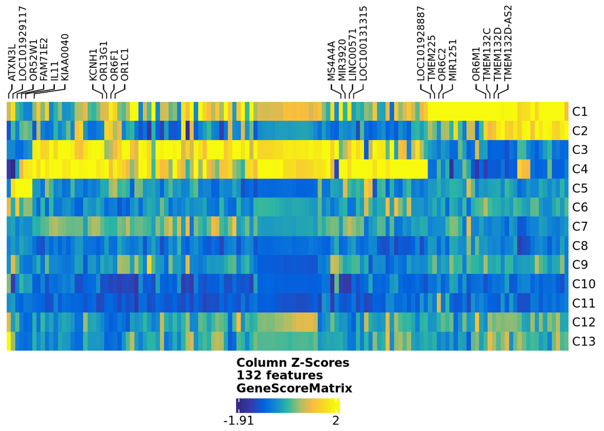

```r
se <- getMarkerFeatures(
  ArchRProj = projMulti2,
  groupBy = "Clusters_Combined",
  bias = c("TSSEnrichment", "log10(nFrags)", "log10(Gex_nUMI)"))

heatmap_gex <- plotMarkerHeatmap(
  seMarker = se,
  cutOff = "FDR <= 0.01 & Log2FC >= 1.5",
  nLabel = 4,
  transpose = TRUE
)
##  [1] "LOC101928887" "TMEM225"      "OR6C2"        "MIR1251"      "OR6M1"
##  [6] "TMEM132C"     "TMEM132D"     "TMEM132D-AS2" "KCNH1"        "OR13G1"
## [11] "OR6F1"        "OR1C1"        "MS4A4A"       "MIR3920"      "LINC00571"
## [16] "LOC100131315" "LOC101929117" "OR52W1"       "FAM71E2"      "IL11"
## [21] "KIAA0040"     "ATXN3L"

plotPDF(draw(heatmap_gex, heatmap_legend_side = "bot", annotation_legend_side = "bot"),
        name="Heatmap-ClusterMarkers",addDOC = FALSE)
```

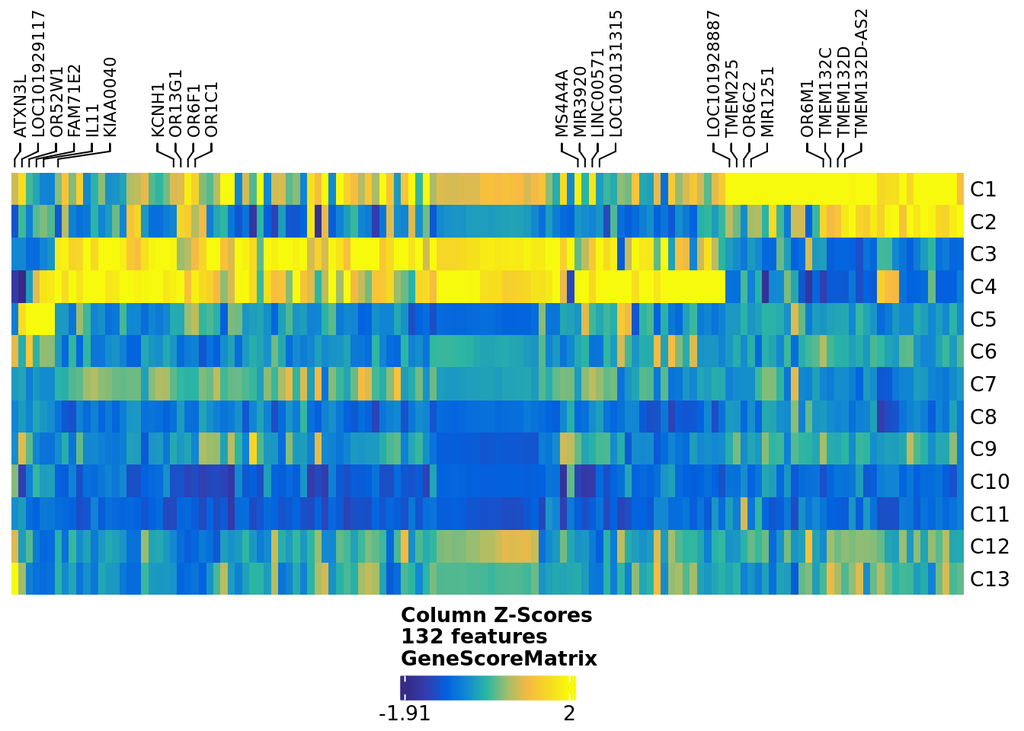

```r
draw(heatmap_gex, heatmap_legend_side = "bot", annotation_legend_side = "bot")
```

```r
#We can get a list of DataFrame objects, one for each of our clusters,
#containing the relevant marker features using the getMarkers() function.
markerList <- getMarkers(se, cutOff = "FDR <= 0.01 & Log2FC >= 1.5")

#save the marker genes object by cluster
saveRDS(se, file = paste0("/gstore/scratch/u/lucast3/fibroticmemory/Save-ProjMulti2/", "markers_Cluster.rds"))
```

Lets add in metadata for groups

## Group Markers

```r
group <- factor(projMulti2$Sample)
treatment <- factor(projMulti2$Sample)
levels(group) <- c(rep("Normal",4),rep("IPF",4))
levels(treatment) <- c("Normal-NoTreatment","Normal-OSM","Normal-TGF",
                       "Normal-IL13","IPF-NoTreatment","IPF-OSM",
                       "IPF-TGF","IPF-IL13")

projMulti2$Group <- as.character(group)
projMulti2$Treatment <- as.character(treatment)

markersGS <- getMarkerFeatures(
  ArchRProj = projMulti2,
  groupBy = "Group",
  bias = c("TSSEnrichment", "log10(nFrags)", "log10(Gex_nUMI)"),
  testMethod = "wilcoxon"
)

heatmap_gex <- plotMarkerHeatmap(
  seMarker = markersGS,
  cutOff = "FDR <= 0.01 & Log2FC >= 1.5",
  nLabel = 4,plotLog2FC = TRUE,
  transpose = TRUE
)
```

```
## [1] "LOC105378311" "MIR548F1"     "TRHDE"        "TRHDE-AS1"    "LOC105369507"
## [6] "SNORD115-39"  "SNORD115-41"  "SOX11"
```

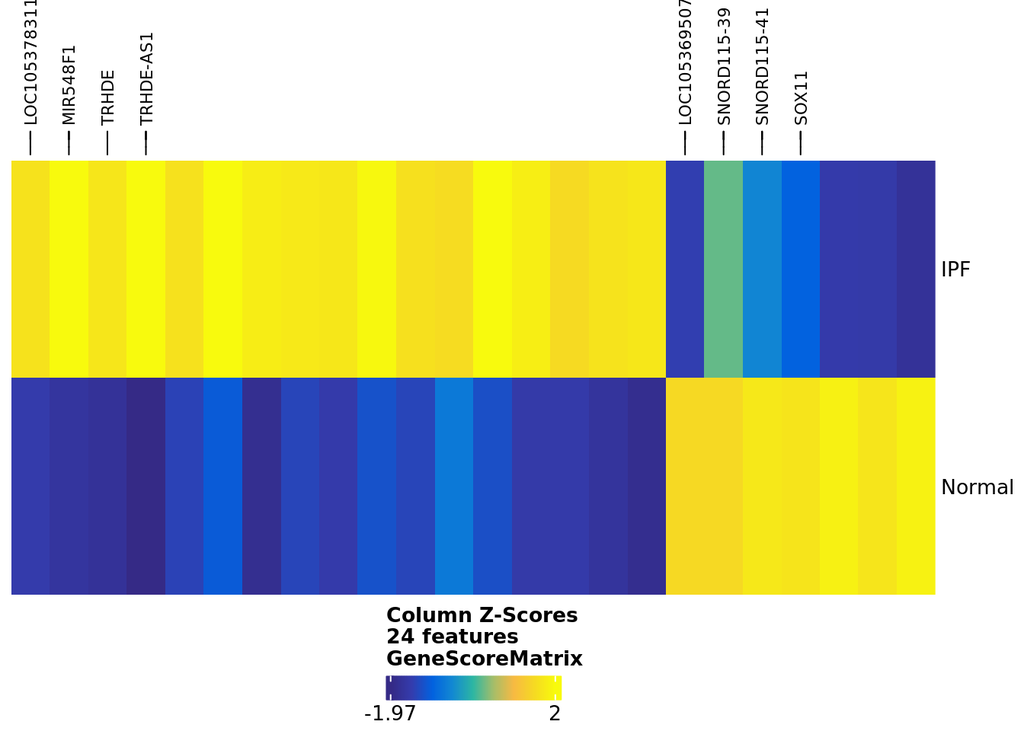

```r
plotPDF(draw(heatmap_gex, heatmap_legend_side = "bot", annotation_legend_side = "bot"),
        name="HeatmapGroupmarkers",addDOC = FALSE)
```

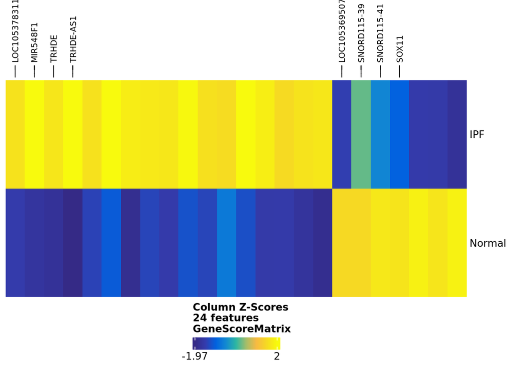

```r
draw(heatmap_gex, heatmap_legend_side = "bot", annotation_legend_side = "bot")
```

```r
#save the marker genes object by samples
saveRDS(markersGS, file = paste0("/gstore/scratch/u/lucast3/fibroticmemory/Save-ProjMulti2/", "markers_Group.rds"))
```

## Treatment Markers

```r
markersGS <- getMarkerFeatures(
  ArchRProj = projMulti2,
  groupBy = "Treatment",
  bias = c("TSSEnrichment", "log10(nFrags)", "log10(Gex_nUMI)"),
  testMethod = "wilcoxon"
)

heatmap_gex <- plotMarkerHeatmap(
  seMarker = markersGS,
  cutOff = "FDR <= 0.01 & Log2FC >= 1",
  nLabel = 4,plotLog2FC = TRUE,
  transpose = TRUE
)
```

```
##  [1] "ECM1"         "DACH1"        "MIR493"       "MIR433"       "OR10J1"
##  [6] "OR10J5"       "LINC01351"    "LOC105378311" "LINC01040"    "LINC00353"
## [11] "LOC105378397" "OR52W1"       "C3orf85"      "MIR6750"      "KRT9"
## [16] "MIR3918"      "EIF1AX-AS1"   "C17orf77"     "SOX11"        "LOC285889"
## [21] "SNORD114-17"  "SNORD114-18"  "SNORD114-26"  "SNORD114-27"
```

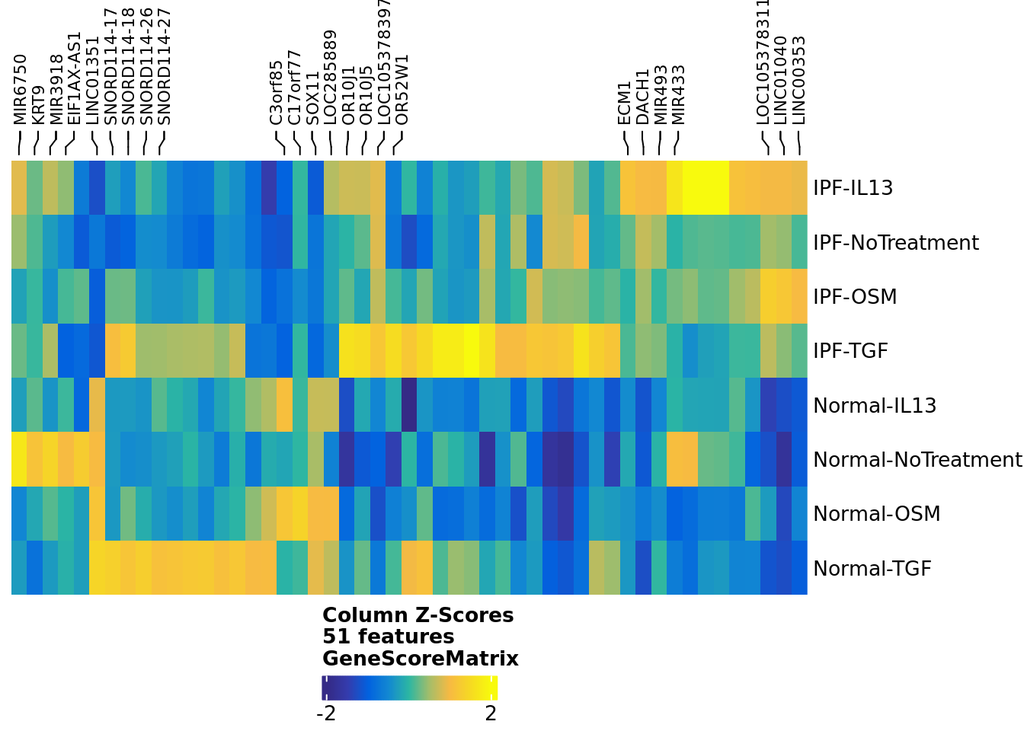

```r
plotPDF(draw(heatmap_gex, heatmap_legend_side = "bot", annotation_legend_side = "bot"),
        name="HeatmapTreamentMarkers",addDOC=FALSE)
```

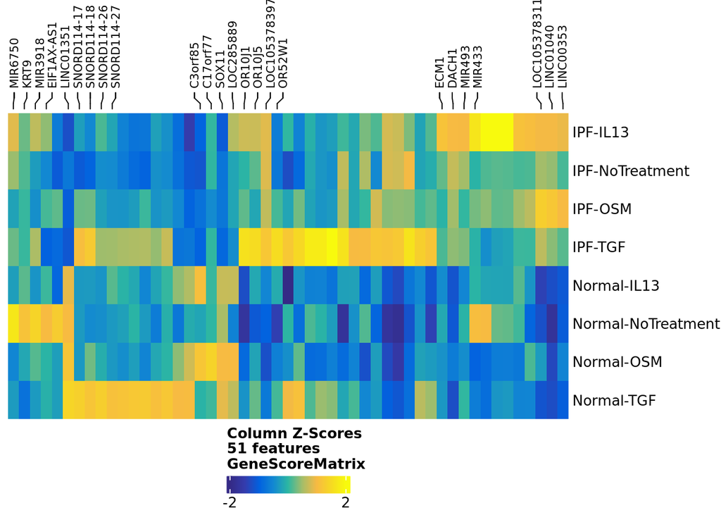

```r
draw(heatmap_gex, heatmap_legend_side = "bot", annotation_legend_side = "bot")
```

```r
#save the marker genes object by samples
saveRDS(markersGS, file = paste0("/gstore/scratch/u/lucast3/fibroticmemory/Save-ProjMulti2/", "markers_Treatment.rds"))
```

# Marker peaks (ie. Differential Peaks)

```r
projMulti2 <- addPeakMatrix(projMulti2,force=TRUE)
getAvailableMatrices(projMulti2)
```

```
## [1] "GeneExpressionMatrix" "GeneScoreMatrix"      "MotifMatrix"
## [4] "PeakMatrix"           "TileMatrix"
```

```r
markersPeaks <- getMarkerFeatures(
  ArchRProj = projMulti2,
  useMatrix = "PeakMatrix",
  groupBy = "Clusters_Combined",
  bias = c("TSSEnrichment", "log10(nFrags)","log10(Gex_nUMI)"),
  testMethod = "wilcoxon"
)

#DE Peaks by Sample
markerList <- getMarkers(markersPeaks, cutOff = "FDR <= 0.01 & Log2FC >= 1")
saveRDS(markerList, file = paste0("/gstore/scratch/u/lucast3/fibroticmemory/Save-ProjMulti2/", "markerPeaks.rds"))
```

```r
#visualizing marker peaks as a heatmap
heatmapPeaks <- plotMarkerHeatmap(
  seMarker = markersPeaks,
  cutOff = "FDR <= 0.001 & Log2FC >= 3",
  transpose = TRUE
)
```

```
##  [1] "chr1:1561938-1562438"     "chr1:1562710-1563210"
##  [3] "chr1:1565257-1565757"     "chr1:2104799-2105299"
##  [5] "chr1:6222617-6223117"     "chr1:7419300-7419800"
##  [7] "chr1:12636377-12636877"   "chr1:17869714-17870214"
##  [9] "chr1:21537966-21538466"   "chr1:21857434-21857934"
## [11] "chr1:22259440-22259940"   "chr1:24699621-24700121"
## [13] "chr1:25371692-25372192"   "chr1:30807346-30807846"
## [15] "chr1:31243875-31244375"   "chr1:32100336-32100836"
## [17] "chr1:33410116-33410616"   "chr1:41862885-41863385"
## [19] "chr1:203406461-203406961" "chr1:212958065-212958565"
## [21] "chr1:230509446-230509946" "chr11:33614120-33614620"
## [23] "chr11:86559244-86559744"  "chr12:98752738-98753238"
## [25] "chr13:26459491-26459991"  "chr15:83698197-83698697"
## [27] "chr16:64910246-64910746"  "chr16:75246406-75246906"
## [29] "chr16:87583461-87583961"  "chr17:32569350-32569850"
## [31] "chr18:48902981-48903481"  "chr18:62616368-62616868"
## [33] "chr1:62314363-62314863"   "chr1:103371175-103371675"
## [35] "chr1:112970941-112971441" "chr1:113986736-113987236"
## [37] "chr1:115133413-115133913" "chr1:115445052-115445552"
## [39] "chr1:186532372-186532872" "chr1:207186419-207186919"
## [41] "chr1:215126323-215126823" "chr1:230124606-230125106"
## [43] "chr1:246107453-246107953" "chr10:43734666-43735166"
## [45] "chr10:63084918-63085418"  "chr12:42961299-42961799"
## [47] "chr12:76265738-76266238"  "chr13:32903716-32904216"
## [49] "chr2:133607586-133608086" "chr20:11376970-11377470"
## [51] "chr4:14646773-14647273"   "chr5:66582524-66583024"
## [53] "chr6:74942045-74942545"   "chr18:79933693-79934193"
## [55] "chr2:205650281-205650781" "chr13:59853634-59854134"
## [57] "chr19:23774522-23775022"  "chr2:51734053-51734553"
## [59] "chr4:140106422-140106922" "chr14:72812531-72813031"
```

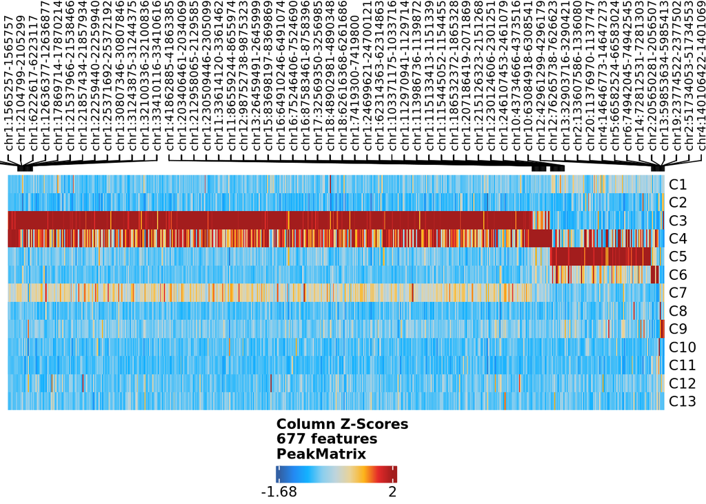

```r
draw(heatmapPeaks, heatmap_legend_side = "bot", annotation_legend_side = "bot")
```

```r
plotPDF(heatmapPeaks, name = "Peak-Marker-Heatmap", width = 8, height = 6, ArchRProj = projMulti2, addDOC = FALSE)
```

# Motif Enrichment

We will perform motif enrichment on our marker peaks to predict what transcription factors may be mediating the binding events that create those accessible chromatin sites.

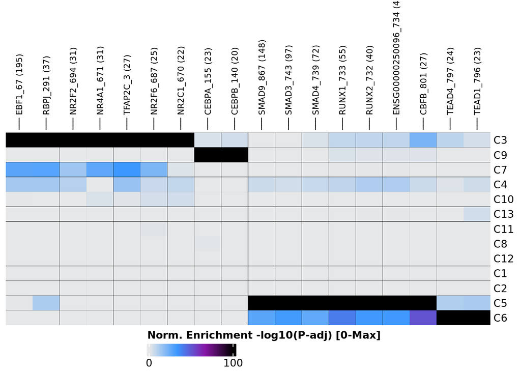

```r
##need to install chromVARmotifs
## devtools::install_github("GreenleafLab/chromVARmotifs")
library(chromVARmotifs)
require(BSgenome.Hsapiens.UCSC.hg38)
projMulti2 <- addMotifAnnotations(ArchRProj = projMulti2, motifSet = "cisbp", name = "Motif",force=TRUE,species = )

enrichMotifs <- peakAnnoEnrichment(
  seMarker = markersPeaks,
  ArchRProj = projMulti2,
  peakAnnotation = "Motif",
  cutOff = "FDR <= 0.01 & Log2FC >= 1"
)

#visualize using heatmap
heatmapEM <- plotEnrichHeatmap(enrichMotifs, n = 7, transpose = TRUE)
ComplexHeatmap::draw(heatmapEM, heatmap_legend_side = "bot", annotation_legend_side = "bot")
```

```r
plotPDF(heatmapEM, name = "Motifs-Enriched-Marker-Heatmap", width = 8, height = 6, ArchRProj = projMulti2, addDOC = FALSE)
```

## ChromVar deviations

chromVAR is designed for predicting enrichment of TF activity on a per-cell basis from sparse chromatin accessibility data. The two primary outputs of chromVAR are:

1. “deviations” - A deviation is a bias-corrected measurement of how far the per-cell accessibility of a given feature (i.e motif) deviates from the expected accessibility based on the average of all cells or samples.
2. “z-score” - The z-score, also known as a “deviation score” is the z-score for each bias-corrected deviation across all cells. The absolute value of the deviation score is correlated with the per-cell read depth. This is because, with more reads, you have higher confidence that the difference in per-cell accessibility of the given feature (i.e. motif) from the expectation is greater than would occur by chance.

```r
projMulti2 <- addBgdPeaks(projMulti2,force=TRUE)

projMulti2 <- addDeviationsMatrix(
  ArchRProj = projMulti2,
  peakAnnotation = "Motif",
  force = TRUE
)

plotVarDev <- getVarDeviations(projMulti2, name = "MotifMatrix", plot = TRUE)
```

[output not shown]

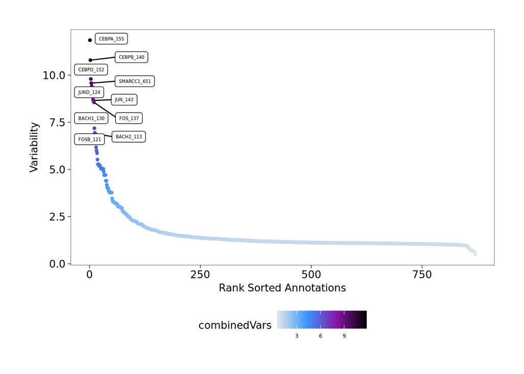

```r
plotVarDev
```

# Final Save

```r
saveArchRProject(ArchRProj = projMulti2,  load = FALSE)
```